# Lineage Designation and Assignment

## Lineage Designation

Lineage designation is an initial step to identify all the lineages contained within a set of sequences, defined by an existing set of rules as recommended in Rambaut et al. (2020), and name them accordingly.

The designation requires some initial steps to be undertaken on the sequences first. They need to be aligned (it’s recommended to use MAFFT and use the FFT-NS-2 algorithm), and then a tree created including bootstrapping (recommended using IQTREE2 with model selection and 100 bootstrap replicates or 1000 ultrafast bootstrap replicates). The ancestral sequences then need to be reconstructed (recommend using Treetime ancestral).

The lineage designation function requires the the tree, alignment, ancestral reconstructions and metadata of the sequences. The sequence IDs must match between all of these. The metadata file must have a column called ‘ID’ which contains the ID’s for all the sequences. It also must have a column called ‘year’ that contains the collection year of each sequence. Additionally, it must have a column called ‘country’. This should contain the country of origin of each sequence. If you don’t have this information, you can leave the column blank but it needs to exist. If you have more detailed information about the origin of the sequence (e.g. a state) you can put this in the country column instead of the country. It also needs to have an ‘assignment’ column which contains any known clade assignments. If you don’t have this information, you can leave this column blank but it needs to exist.

The fuction undertakes the following steps: Lineage defining nodes are identified according to thresholds on bootstrap support (>70, or >90 for ultrafast bootstrapping) and cluster size (>10 descendents of >95% coverage, excluding gaps and ambiguous bases). For each node still in consideration, the ancestral sequence is extracted. To define a new lineage, there must be at least one SNP between the ancestral sequence and its descendents that is shared between all sequences in the cluster. The lineages are then named according to Rambaut et al. (2020), but integrating any existing assignments if they are present.

There are two functions as part of lineage designation that work in the same way, but return different results:

seq_designation() returns a lineage designation and information about each sequence.

node_info() returns each of the defining nodes of the designations, with information about them.

```r
sequence_designation<-seq_designation(tree, 90, alignment, metadata, ancestral)
defining_node_information<-node_info(tree, 90, alignment, metadata, ancestral)
names(defining_node_information)<-c("node", "n_tips", "diff", "overlaps", "lineage", "numbers")
```

```r
head(sequence_designation, 20)
```

```
##          ID n_N n_gap length year                  lineage          previous
## 1  KF155002   0     0  11922 2010                     <NA> Cosmopolitan AF1b
## 2  KR534217   0     0  11922 2008 Cosmopolitan AF1b_A1.1.1 Cosmopolitan AF1b
## 3  KR534218   0     0  11922 2008 Cosmopolitan AF1b_A1.1.1 Cosmopolitan AF1b
## 4  KR534219   0     0  11922 2007     Cosmopolitan AF1b_C1 Cosmopolitan AF1b
## 5  KR534220   0     0  11922 2008 Cosmopolitan AF1b_A1.1.1 Cosmopolitan AF1b
## 6  KR534228   0     9  11913 2010     Cosmopolitan AF1b_C1 Cosmopolitan AF1b
## 7  KR534229   0    73  11849 2010     Cosmopolitan AF1b_B1 Cosmopolitan AF1b
## 8  KR534230   0    37  11885 2010   Cosmopolitan AF1b_C1.1 Cosmopolitan AF1b
## 9  KR534231   0    38  11884 2010     Cosmopolitan AF1b_C1 Cosmopolitan AF1b
## 10 KR534232   0     0  11922 2011     Cosmopolitan AF1b_B1 Cosmopolitan AF1b
## 11 KR534233   0     0  11922 2011     Cosmopolitan AF1b_B1 Cosmopolitan AF1b
## 12 KR534234   0     0  11922 2011     Cosmopolitan AF1b_C1 Cosmopolitan AF1b
## 13 KR534235   0     0  11922 2011     Cosmopolitan AF1b_D1 Cosmopolitan AF1b
## 14 KR534236   0     0  11922 2011     Cosmopolitan AF1b_D1 Cosmopolitan AF1b
## 15 KR534237   0     0  11922 2011     Cosmopolitan AF1b_D1 Cosmopolitan AF1b
## 16 KR534238   0    57  11865 2011     Cosmopolitan AF1b_C1 Cosmopolitan AF1b
## 17 KR534244   0     9  11913 2011 Cosmopolitan AF1b_B1.1.1 Cosmopolitan AF1b
## 18 KR534245   0     0  11922 2011 Cosmopolitan AF1b_B1.1.1 Cosmopolitan AF1b
## 19 KR534246   0     0  11922 2011 Cosmopolitan AF1b_B1.1.1 Cosmopolitan AF1b
## 20 KR534247   0     0  11922 2011   Cosmopolitan AF1b_B1.1 Cosmopolitan AF1b
```

```r
defining_node_information
```

```
##    node n_tips diff overlaps                  lineage numbers
## 3   209    183    5       25     Cosmopolitan AF1b_A1       1
## 7   213    176   21       21   Cosmopolitan AF1b_A1.1       2
## 11  217    100   19       12 Cosmopolitan AF1b_A1.1.1       3
## 19  228     49  216        4     Cosmopolitan AF1b_B1       4
## 25  235     42  399        3   Cosmopolitan AF1b_B1.1       5
## 69  329     71   57        3 Cosmopolitan AF1b_A1.1.2       6
## 70  332     58   92        2     Cosmopolitan AF1b_C1       7
## 28  239     35  275        0 Cosmopolitan AF1b_B1.1.1       8
## 45  281     21  299        0     Cosmopolitan AF1b_D1       9
## 55  301     19   30        0     Cosmopolitan AF1b_E1      10
## 75  355     23  299        0   Cosmopolitan AF1b_C1.1      11
```

An additional function can be run to find out information about each of the newly designated lineages. It requires the seq_designation output, plus the metadata.

```r
lineage_info<-lineage_info(sequence_designation, metadata) ; lineage_info
```

```
## # A tibble: 11 × 5
##    lineage                  country  year_first year_last n_seqs
##    <chr>                    <chr>         <int>     <int>  <int>
##  1 Cosmopolitan AF1b_A1     Tanzania       2009      2017      7
##  2 Cosmopolitan AF1b_A1.1   Tanzania       2003      2018      6
##  3 Cosmopolitan AF1b_A1.1.1 Tanzania       2004      2012     11
##  4 Cosmopolitan AF1b_A1.1.2 Tanzania       2008      2013     13
##  5 Cosmopolitan AF1b_B1     Tanzania       2010      2013      7
##  6 Cosmopolitan AF1b_B1.1   Tanzania       2011      2018     10
##  7 Cosmopolitan AF1b_B1.1.1 Tanzania       2010      2013     35
##  8 Cosmopolitan AF1b_C1     Tanzania       1996      2017     38
##  9 Cosmopolitan AF1b_C1.1   Tanzania       2010      2013     23
## 10 Cosmopolitan AF1b_D1     Tanzania       2010      2013     21
## 11 Cosmopolitan AF1b_E1     Tanzania       2011      2017     28
```

## Lineage Assignment

Lineage assignment identifes which existing lineage, determined by lineage designation, a new sequence belongs to.

The function requires the test sequences in fasta format, and will return information about their assignments.

```r
assignments<-assign_lineages(sequences, "RABV"); assignments
```

```
##      ID              lineage lineage_countries_seen lineage_first_seen
## 1 test1 Cosmopolitan AM3b_B1                 Brazil               2006
## 2 test2 Cosmopolitan AM3b_B1                 Brazil               2006
##   lineage_last_seen
## 1              2009
## 2              2009
```

## Visualising Lineages

This group of Lineage Figure functions produce figures to assist in interpretation of lineage data.

They all require the outputs of the lineage designation functions; seq_designation, node_info and lineage_info, as well as the tree and metadata used for lineage designation. The colour schemes across all the figures are comparable.

The sunburst function produces a sunburst plot to visualise the hierarchical relationship of the lineages.

```r
sunburst(lineage_info, defining_node_information, tree, metadata, sequence_designation)
```

[interactive chart not shown]

The lineage_tree function produces a lineage tree with a lineage bar to visualise the phylogenetic positions of the lineages.

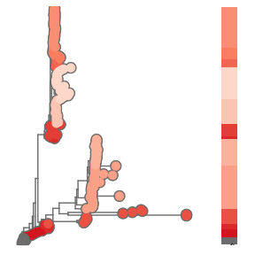

```r
lineage_tree(lineage_info, defining_node_information, tree, metadata, sequence_designation)
```